# Lab 04

EE 509 - completed by Rose Abramoff

This week’s lab will continue our exploration of analytical and numerical approaches to fitting models by maximum likelihood. Most of the techniques will remain the same but we will be looking at a model of greater complexity.

## Case Study: Effects of Elevated CO2 on Pine Fecundity

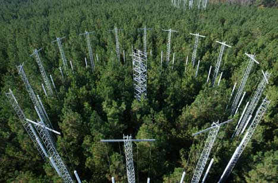

The response of ecosystems to elevated CO2 involves not just the change in growth rates of plants, but also the change in their survival and reproduction. This week’s analysis will look at the response of loblolly pine (Pinus taeda) to being grown in both elevated and ambient CO2 under field conditions at a FACE (Free Air CO2 Enrichment) site in North Carolina (LaDeau and Clark 2001). Part of this data set consists of counts of the number of pine cones on trees in both treatments. Trees of different sizes are known to vary in their reproductive output, with larger trees being more fecund. Because we know that the trees under elevated CO2 are growing faster, and thus are on average larger, this analysis will need to account for tree size as a covariate to determine if trees in elevated CO2 produce more seed at a given size (i.e. fecundity | size) or if the increase in fecundity under elevated CO2 is just due to an increase in tree size. This experiment fortuitously began right as the trees were starting to mature, so there is the additional question of whether CO2 affects the size at which trees reach maturity.

Lets begin by loading up the data and taking a look at it

```r
b = read.table("data/pinecones.txt",header=TRUE)

str(b)
```

```
## 'data.frame':    644 obs. of  7 variables:
##  $ id  : int  1 2 3 4 5 6 7 8 9 10 ...
##  $ ring: int  1 1 1 1 1 1 1 1 1 1 ...
##  $ tmt : Factor w/ 2 levels "AMB","CO2": 1 1 1 1 1 1 1 1 1 1 ...
##  $ diam: num  19.4 14.1 19.4 21.6 10.8 19.8 6.1 15.5 16.1 5.8 ...
##  $ c98 : int  0 0 0 0 0 0 0 0 0 0 ...
##  $ c99 : int  0 0 6 0 0 0 0 0 0 0 ...
##  $ c00 : int  0 4 0 0 0 0 0 0 0 0 ...
```

```r
summary(b)
```

```
##        id           ring       tmt           diam           c98
##  Min.   :  1   Min.   :1.00   AMB:347   Min.   : 2.6   Min.   :0.000
##  1st Qu.:162   1st Qu.:2.00   CO2:297   1st Qu.:12.6   1st Qu.:0.000
##  Median :322   Median :4.00             Median :16.9   Median :0.000
##  Mean   :322   Mean   :3.78             Mean   :16.0   Mean   :0.064
##  3rd Qu.:483   3rd Qu.:5.00             3rd Qu.:19.6   3rd Qu.:0.000
##  Max.   :644   Max.   :6.00             Max.   :28.6   Max.   :8.000
##       c99             c00
##  Min.   : 0.00   Min.   : 0.00
##  1st Qu.: 0.00   1st Qu.: 0.00
##  Median : 0.00   Median : 0.00
##  Mean   : 1.83   Mean   : 2.39
##  3rd Qu.: 0.00   3rd Qu.: 1.00
##  Max.   :59.00   Max.   :91.00
```

```r
table(b$ring,b$tmt)           ## shows number of trees by ring and treatment
```

```
##
##     AMB CO2
##   1  96   0
##   2   0  71
##   3   0 109
##   4   0 117
##   5 104   0
##   6 147   0
```

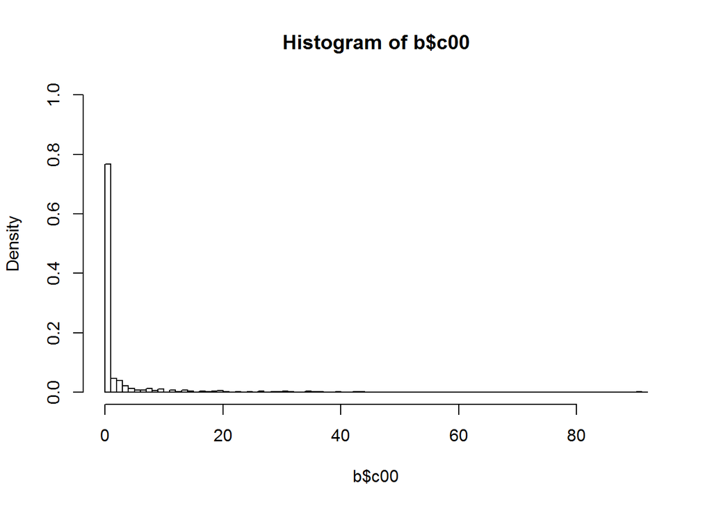

```r
##histogram of cone counts
hist(b$c00,breaks=0:92,probability=TRUE,ylim=c(0,1))
```

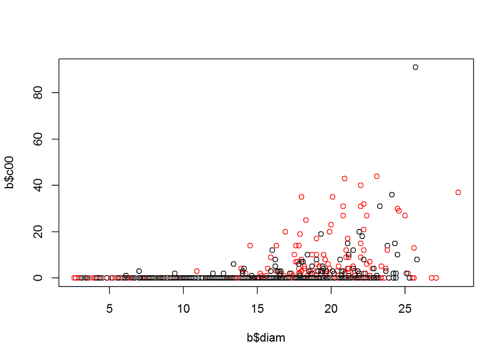

```r
##plot of counts by tree size (x-axis) and CO2 (AMB is black, CO2 is red)
plot(b$diam,b$c00,col = b$tmt)
```

The rows in this data set represent observations of individual trees. The first column in the data set is an ID number (id). The second (ring) is an indicator of which plot the tree was in – there are 6 circular plots at the FACE experiment. The third (tmt) indicated which treatments were applied to which rings, where AMB refers to ambient CO2 concentrations and CO2 refers to elevated CO2. The next column (diam) gives the diameter of the tree at 1.3 m height (diameter breast height) in centimeters. Other measures of tree size (height, mass, etc.) are highly correlated with diameter. The final three columns are the cone counts in 1998 (c98), 1999 (c99), and 2000 (c00). To keep the analysis more manageable we’ll focus on just the data from 2000.

### Fecundity Model

For the first phase of our analysis lets focus on the relationship between fecundity (cone count) and tree size (diameter). Since the number of cones that are produced on a mature individual is positive count data lets assume that cone production, y, is Poisson

$L = \prod_{i=1}^{n} Pois \left( y_i \vert g(x_i) \right)$

where the expected number of cones per tree, g, is a function of tree diameter. Now that we have specified the data model for our analysis we next need to specify the process model, which is the function g(x). For g(x) there is some evidence that fecundity increases as the square of diameter, so we will model g as

$g(x_i) = a_0 x_i^2$

Before we get to fitting the model, lets define some variables that specify what data is going to be used in the fitting

```r
dia     = b$diam        ## tree diameters
cones = (b$c00 > 0)     ## whether cones are present – this indicates whether tree is mature
ncone = b$c00           ## number of cones in 2000
tmt     = b$tmt         ## treatment (elevated vs ambient)
```

Next, lets define our negative log likelihood function for this model

```r
likFec = function(a0,x,y){
  g <- a0*x^2             ## expected mean fecundity, g(x),as a function of tree size
  -sum(dpois(y,g,log=TRUE)) ## negative log likelihood
}
```

To try and make the distinction between the data model and the process model clear we’ve split this R function into two lines, one that calculates g(x), the expected number of cones for a tree of a given size, and the second that calculated the negative log likelihood.

Now that we have our likelihood function, we’ll want to fit it numerically and then take a look at the results, both in terms of the numbers returned and in a basic graph of the fit of the model. As a first pass, lets consider all data from both treatments together

```r
out.fec = optimize(likFec,c(0.001,1),x=dia,y=ncone)
out.fec
```

```
## $minimum
## [1] 0.008494
##
## $objective
## [1] 2563
```

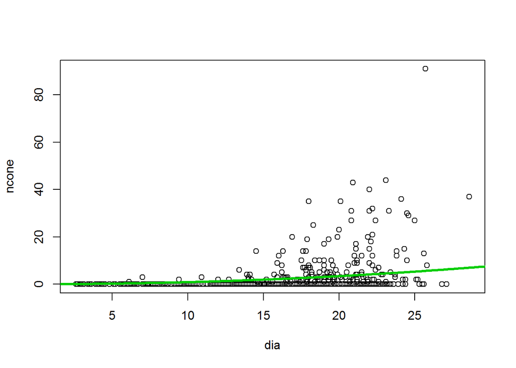

```r
a0 = out.fec$minimum

plot(dia,ncone)
dseq = seq(1,30,length=300)
lines(dseq,a0*dseq^2,col=3,lwd=3)
```

## Combined Fecundity and Maturation

From the exploratory data analysis and this initial model of tree fecundity it is clear that there are a large number of trees with a cone count of zero every year and that smaller trees are likely to be reproductively immature. Therefore our data model needs to account for both the status of the plant (reproductively mature vs. immature) and the variability associated with the count data of the number of cones. We have already discussed the later part in the fecundity model above so lets take a look at reproductive maturation. Since maturation is boolean in nature, but a function of tree size, lets treat it as a Bernoulli process

$Bernoulli \left( m_i \vert \theta(x_i) \right)$

where m is the status of a tree being mature and $\theta$, the probability of being mature, is some function of tree diameter, x. Recall that the Bernoulli is just a special case of the Binomial where the sample size is 1 (i.e. a single coin toss with some specified probability) If we observe cones on a tree (y > 0) it must be mature (m = 1) and thus the probability of this observation is

$p(y_i = 1,2,\dotsc) = Bernoulli \left( m = 1 \vert \theta (x_i) \right) Pois \left( y_i \vert g(x_i) \right)$ (1a)

This likelihood involves both the probability that an individual is mature and the number of cones that were produced given that the individual was mature. The probability of zero cones involves two terms, that of an individual being immature and that of it being mature but with no cones are observed.

$p(y_i = 0) = Bernoulli \left( m = 0 \vert \theta (x_i) \right) + Bernoulli \left( m = 1 \vert \theta (x_i) \right) Pois \left( 0 \vert g(x_i) \right)$ (1b)

The inclusion of these two terms in the model for zero counts makes it clear that both process models,  (x) and g(x), have to be fit simultaneously because fitting them individually would miss the fact that some of the trees with a zero count are actually mature. Now that we have specified the data models for our analysis and the process model for g(x), the relationship between size and fecundity, we next need to specify the process model for $\theta(x)$, the relationship between tree size and maturation. For $\theta(x)$ we will need a function that spans the range of diameters and goes from 0 to 1 in the y axis. One function that meets this criteria is the probit function, $probit(b_0,b_1)$ which has the same functional form as the normal CDF (pnorm in R). The probit has a nice intuitive interpretation in that the b0 of the function, which is analogous to the mean, determines its midpoint (x value where the probability is 0.5) and the b1, which is analogous to the variance, determines the steepness of the curve.

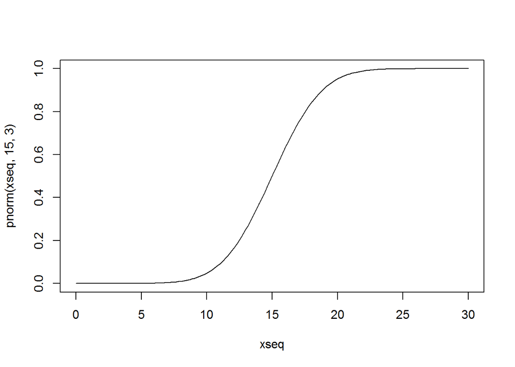

```r
## example of probit
xseq = seq(0,30,length=200)
plot(xseq,pnorm(xseq,15,3),type='l')
```

Lab Report Task 1

In fitting the model numerically we’re going to need some initial conditions for the routine to start from. **Make two plots showing fecundity (dia vs ncone) and maturation (dia vs cones)**. For each of these plots **add different colored lines for $g(x)$ and $g(x) \cdot \theta(x)$ to the fecundity plot and $\theta(x)$ to the maturation plot**. Choose the parameters for these functions (a0, b0, b1) so that they produce plots that are reasonable initial conditions given the data – this can be done simply by a bit of trial and error. Specify the values for (a0, b0, b1) in R as a vector named “param”.

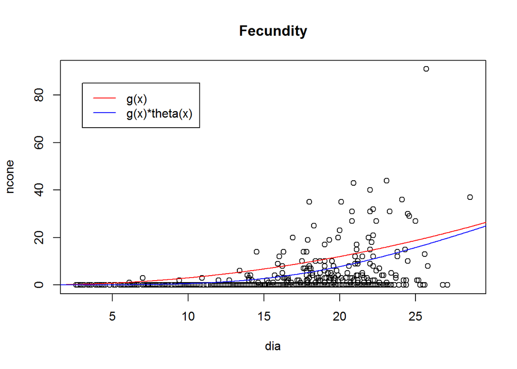

```r
rseq <- seq(1,30,length = 644)
g <- a0*rseq^2
theta <- pnorm(rseq,b0,b1)
#Fecundity plot
plot(dia,ncone,main = "Fecundity")
lines(rseq, g, col="red")
lines(rseq, g*theta,col="blue")
legend(3,85, c("g(x)", "g(x)*theta(x)"), lty=c(1,1), col=c("red","blue"))
```

[output not shown]

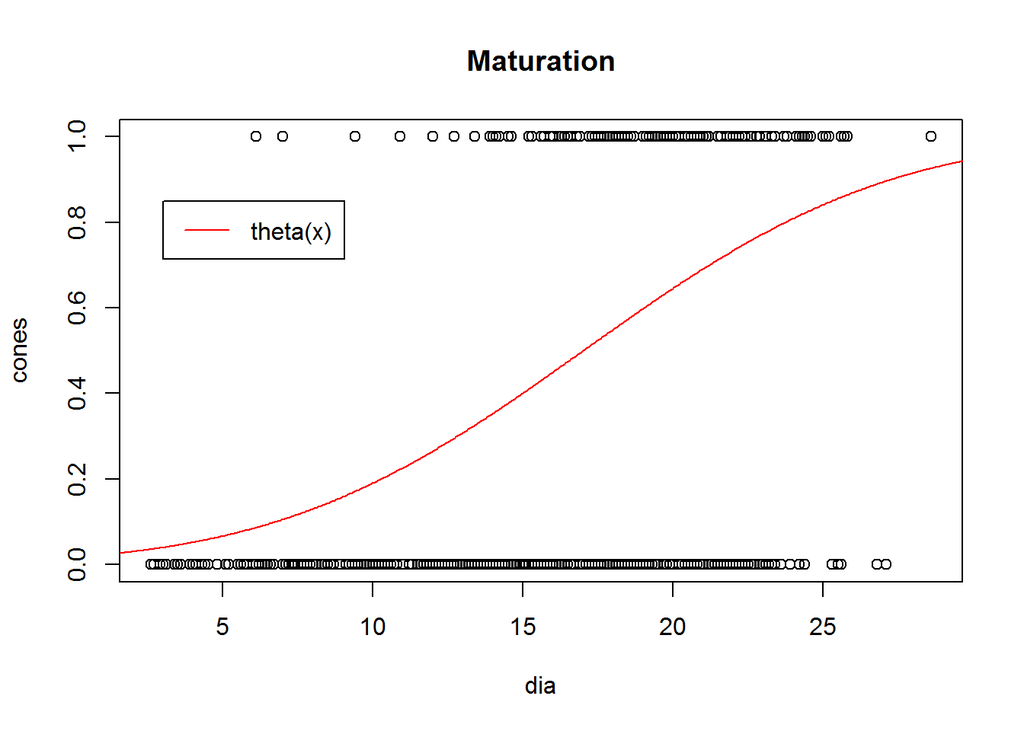

```r
#Maturation plot
plot(dia,cones,main = "Maturation")
lines(rseq, theta, col="red")
legend(3,0.85,"theta(x)", lty=1, col="red")
```

This vector will be passed to our likelihood function below. When choosing initial conditions, they don’t have to be a great fit – finding that great fit is the job of the likelihood analysis – they just have to be in the right ballpark (e.g. your curves should show up on the plot of the data). For this task you will turn in your two plots, your R code, and your param vector

Now lets put all this together in order to define the likelihood function. This function will be a bit more complicated that the simple functions we defined last week, or the fecundity-only likelihood we defined above, and will include a likelihood that has two parts (when cone counts are zero vs positive) and a “return” statement that defines what the function returns when it is done. Return statements are optional but useful for more complex functions in order to be explicit about what is being returned.

```r
likfit = function(param,dia,ncone){
  a0 = param[1]
  b0 = param[2]
  b1 = param[3]
  cones = ncone > 0

  ## trees with cones
  dia.cone  = dia[cones > 0]                ##find just the trees with cones
  g.cone = a0 * dia.cone^2          ## Fecundity fnc - g(x)
  theta.cone    = pnorm(dia.cone,b0,b1,log.p=TRUE)  ## maturation probit
  prob.cone = theta.cone + dpois(ncone[cones],g.cone,log=TRUE)

  ##trees with zero counts
  dia.zero  = dia[cones == 0]
  g.zero = a0 * dia.zero^2
  theta.zero    = pnorm(dia.zero,b0,b1)     ##maturation probit
  prob.zero = log((1-theta.zero) + theta.zero*dpois(0,g.zero))

  return(-sum(prob.cone,prob.zero))
}
```

Within this function the $dia.*$ lines define the subsets of data that are relevant for each condition. The $g.*$ line defines the expected value for g(x), the number of cones per tree. The $theta.*$ line defines the $\theta$ function. The $prob.*$ line defines the log likelihood for each part corresponding to equations 1a and 1b above. Take a look at those functions and be sure you understand how they were converted into the calculations above. Finally, the return line calculates the total negative log likelihood by summing up the two terms of the likelihood function.

Having defined the likelihood function the next step is to numerically minimize the negative log likelihood

```r
out = optim(param,
             likfit,
             lower=c(0.001,10,1),
             upper=c(1,30,10),
             method="L-BFGS-B",dia=dia,ncone=ncone)
a0  = out$par[1]
b0  = out$par[2]
b1  = out$par[3]
lnL = out$value
n   = length(cones)
out
```

```
## $par
## [1]  0.02351 21.85811  7.34481
##
## $value
## [1] 1297
##
## $counts
## function gradient
##       43       43
##
## $convergence
## [1] 0
##
## $message
## [1] "CONVERGENCE: REL_REDUCTION_OF_F <= FACTR*EPSMCH"
```

Lab Report Task 2

Create new figures that add curves representing the MLE fits to the figures you created in task 1. Also, include the maximum likelihood estimates of the parameters in your lab report

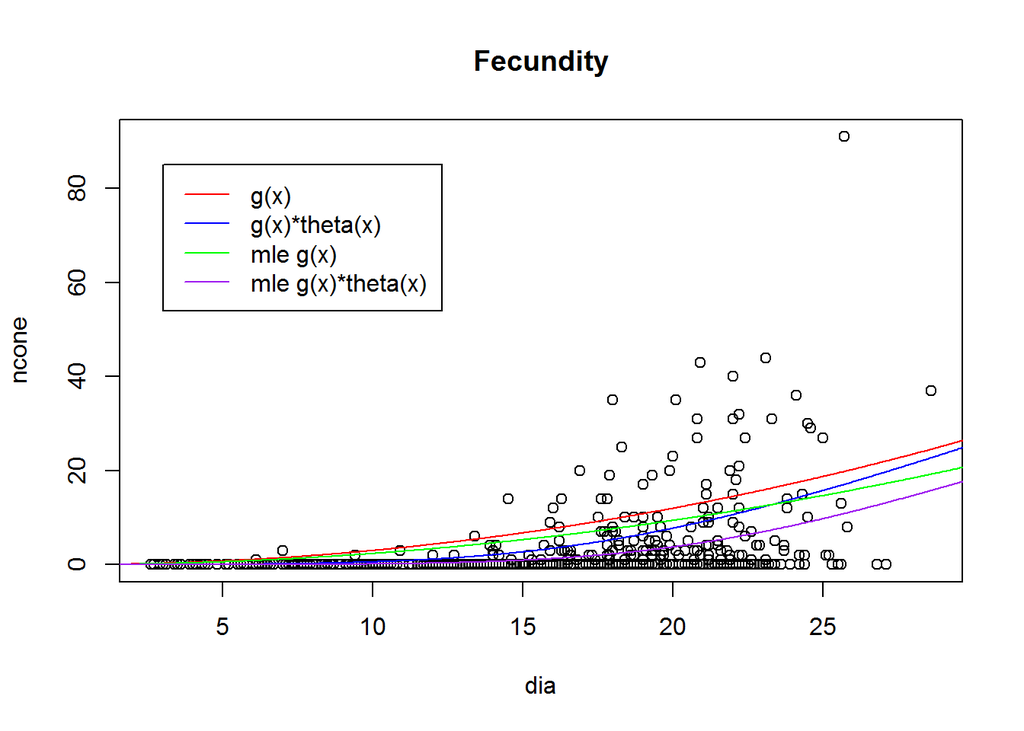

```r
    a0 = 0.03
    b0 = 17
    b1 = 8
g <- a0*rseq^2
theta <- pnorm(rseq,b0,b1)
gmle <- out$par[1]*rseq^2
thetamle <- pnorm(rseq,out$par[2], out$par[3])
#Fecundity plot
plot(dia,ncone,main = "Fecundity")
lines(rseq, g, col="red")
lines(rseq, g*theta,col="blue")
lines(rseq, gmle, col="green")
lines(rseq, gmle*thetamle, col="purple")
legend(3,85, c("g(x)", "g(x)*theta(x)", "mle g(x)", "mle g(x)*theta(x)"), lty=c(1,1,1,1), col=c("red","blue", "green", "purple"))
```

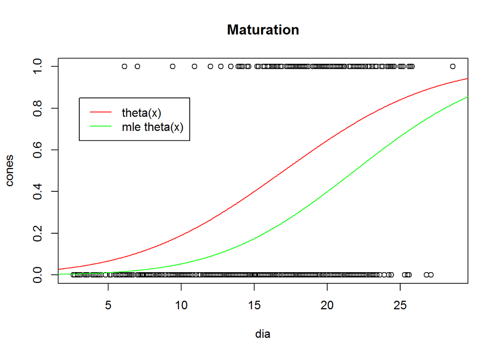

```r
#Maturation plot
plot(dia,cones,main = "Maturation")
lines(rseq, theta, col="red")
lines(rseq, thetamle, col="green")
legend(3,0.85, c("theta(x)", "mle theta(x)"), lty=c(1,1), col=c("red","green"))
```

## Effects of Elevated CO2 on Reproduction

Now, you may have noticed that the likelihood we wrote made no use of the CO2 treatment information. We began by fitting the model to the whole data set. We are next going to fit the model to the ambient and elevated data separately and then compare the fit of the data for the model with a treatment effect to the fit without the effect. In this approach we are choosing a biologically relevant null model – that fecundity and maturation vary with size but not CO2 – as opposed to simply testing whether each of the effects is different from zero. In the remainder of the lab we will introduce concepts related to hypothesis testing and model comparison that we will not get to in lecture for a few more weeks but which we’d like you to have seen now when you are formulating your ideas for your independent projects.

In order to begin model comparison, lets look at how to fit the model to just the data from the ambient treatment. The first step of this is to extract the subset of data that we are interested in. We will reuse the same variable names we used above because these are the variable names that our likelihood function, likfit, is looking for.

```r
## Ambient
dia.amb   = b$diam[tmt=="AMB"]   ## tree diameters
ncone.amb = b$c00[tmt=="AMB"]    ## number of cones
```

Next, lets fit the same likelihood model that we did previously but save the output to different variables. You’ll notice that since we’ve now defined the data sets used by the likfit function differently all we have to do is re-fit the likelihood function as is.

```r
out.amb = optim(param,likfit,method="L-BFGS-B",
             lower=c(0.001,10,1),upper=c(1,30,10),dia=dia.amb,ncone=ncone.amb)
a0[2]  = out.amb$par[1]
b0[2]  = out.amb$par[2]
b1[2]  = out.amb$par[3]
lnL[2] = out.amb$value
n[2]     = length(cones)
out.amb
```

```
## $par
## [1]  0.01881 23.43086  8.16728
##
## $value
## [1] 521.8
##
## $counts
## function gradient
##       19       19
##
## $convergence
## [1] 0
##
## $message
## [1] "CONVERGENCE: REL_REDUCTION_OF_F <= FACTR*EPSMCH"
```

You can compare the “out” and “out.amb” variables and see that the model has converged to different parameter values, which is to be expected since it is operating on a non-random subset of the full data. In storing the values from the optimization we’re converting each of the variables we defined earlier (a0, b0, etc.) into vectors and storing the values from this analysis as the second element in each of those vectors. This is done just to make comparing their values easier.

Lab Report Task 3

```r
## Ambient
dia.elev   = b$diam[tmt=="CO2"]   ## tree diameters
ncone.elev = b$c00[tmt=="CO2"]    ## number of cones

out.elev = optim(param,likfit,method="L-BFGS-B",
             lower=c(0.001,10,1),upper=c(1,30,10),dia=dia.elev,ncone=ncone.elev)
a0[3]  = out.elev$par[1]
b0[3]  = out.elev$par[2]
b1[3]  = out.elev$par[3]
lnL[3] = out.elev$value
n[3]     = length(cones)
out.elev
```

```
## $par
## [1]  0.02676 21.10526  8.19431
##
## $value
## [1] 750.8
##
## $counts
## function gradient
##       39       39
##
## $convergence
## [1] 0
##
## $message
## [1] "CONVERGENCE: REL_REDUCTION_OF_F <= FACTR*EPSMCH"
```

Finally, we’ll perform a *Likelihood Ratio Test*, which is a statistical test that compared two nested models based on their deviance. Nested models are models that have the same functional form but where the reduced version of the model is achieved by fixing parameter values a priori. For example from last week’s lab the Weibull and Exponential are nested models, where setting the c parameter equal to 1 in the Weibull gives the Exponential. In the current context, the fit of the model to the whole dataset (out) is a nested version of the model with the CO2 treatment where the treatment effect is dropped. In this context we’re considering the two fits of the data to the two treatments (out.amb and out.elev) as one single model that has the same sample size as the single fit but twice as many parameters. As mentioned in lecture, the deviance is defined as -2 log(L). Deviance has a chi-square distribution with the degrees of freedom based on the difference in the number of parameters between two models. In this case the null model has 3 parameters (a0, b0, b1) while the alternate model has six parameters because we have two a0’s (ambient vs elevated), two b0’s and two b1’s.

```r
dev.null = 2*lnL[1]
dev.tmt  = 2*lnL[2] + 2*lnL[3]
dev = dev.null - dev.tmt
pval = 1-pchisq(dev,3)
```

Lab Report Task 4

[figure not shown]

```r
g.full<- a0[1]*rseq^2
g.amb<- a0[2]*rseq^2
g.elev<- a0[3]*rseq^2
theta.full <- pnorm(rseq,b0[1], b1[1])
theta.amb <- pnorm(rseq,b0[2], b1[2])
theta.elev <- pnorm(rseq,b0[3], b1[3])

#Fecundity plot
plot(dia,ncone,main = "Fecundity")
lines(rseq, g.full, col="purple")
lines(rseq, g.full*theta.full, col="purple", lty = 2)
lines(rseq, g.amb, col="red")
lines(rseq, g.amb*theta.amb, col="red", lty = 2)
lines(rseq, g.elev, col="blue")
lines(rseq, g.elev*theta.elev, col="blue", lty = 2)
legend(3,85, c("full g(x)", "full g(x)*theta(x)", "ambient g(x)", "ambient g(x)*theta(x)", "elevated g(x)", "elevated g(x)*theta(x)"), lty=c(1,2,1,2,1,2), col=c("purple", "purple", "red", "red", "blue", "blue"))
```

[figure not shown]

[output not shown]

```r
#Maturation plot
plot(dia,cones,main = "Maturation")
lines(rseq, theta.full, col="purple")
lines(rseq, theta.amb, col="red")
lines(rseq, theta.elev, col="blue")
legend(3,0.85, c("full theta(x)", "ambient theta(x)", "elevated theta(x)"), lty=c(1,1,1), col=c("purple","red","blue"))
```